# データ解析論II第8講

後藤 晶

# 講義資料

## 今日の資料はコチラから．

[figure not shown]

スマホで見る方は**QRコード**を読み込んでください

- 【第1講】イントロダクション
- 【第2講】前期の復習（一般線形モデル）
- 【第3講】一般化線形モデル①
- 【第4講】一般化線形モデル②，一般線形混合モデル
- 【第5講】一般化線形混合モデル- 因子分析①
- 【第6講】因子分析① 因子分析②
- 【第7講】因子分析②**パス解析**
- 【第8講】機械学習①：分類**構造方程式モデリング**
- 【第9講】機械学習②：サポートベクターマシンによる分類
- 【第10講】マッチング法・回帰不連続デザイン
- 【第11講】操作変数法・差の差の分析
- 【第12講】発表準備①
- 【第13講】発表準備②
- 【第14講】発表準備③・プレゼンテーション

### radiantの起動

```r
# library(radiant)
# radiant()
```

## 前回の復習

### 今日は因子分析をいっぱいしてみよう．

- 以下の問題を回答してください．
1. 以下データセットclass_dataには，以前「不確実性下の人間行動」の講義を履修している学生を対象とした調査の結果が入っている．これについて，以下の分析を行うこと

**class_data.csv**

```r
library(DT)
library(readr)
class_data <- read_csv("/Users/akira/Dropbox/Education/2019MEIJI/[3_Wed2]Data_Analytics/analysis/data/class_data.csv")
DT::datatable(class_data)
```

|  | participant.code | participant.label | Trust1_SNS | Trust2_SNS | Trust3_SNS | Trust4_SNS | Trust5_SNS | Trust6_SNS | Trust7_SNS | Trust1_location | Trust2_location | Trust3_location | Trust4_location | Trust5_location | Trust6_location | Trust7_location | Trust1_phistory | Trust2_phistory | Trust3_phistory | Trust4_phistory | Trust5_phistory | Trust6_phistory | Trust7_phistory | Trust1_telcom | Trust2_telcom | Trust3_telcom | Trust4_telcom | Trust5_telcom | Trust6_telcom | … |
| --- | --- | --- | --- | --- | --- | --- | --- | --- | --- | --- | --- | --- | --- | --- | --- | --- | --- | --- | --- | --- | --- | --- | --- | --- | --- | --- | --- | --- | --- | --- |
| 1 | sgjacrnx | 1810160448 | 0 | 0 | 0 | 0 | 5 | 0 | 0 | 0 | 0 | 0 | 0 | 5 | 0 | 0 | 60 | 60 | 60 | 45 | 70 | 20 | 55 | 5 | 10 | 9 | 4 | 16 | 0 | … |
| 2 | 6rnh5qnn | 1810170413 | 60 | 30 | 50 | 60 | 70 | 30 | 50 | 30 | 15 | 30 | 15 | 15 | 0 | 15 | 80 | 40 | 34 | 70 | 34 | 0 | 60 | 60 | 34 | 10 | 40 | 60 | 14 | … |
| 3 | 3pmd5hop | 1810160380 | 0 | 0 | 0 | 0 | 0 | 50 | 0 | 40 | 20 | 0 | 0 | 40 | 0 | 0 | 70 | 0 | 0 | 0 | 0 | 0 | 0 | 0 | 0 | 0 | 0 | 0 | 0 | … |
| 4 | b61psx1g | 1810170102 | 0 | 0 | 0 | 0 | 0 | 0 | 0 | 30 | 27 | 50 | 27 | 44 | 0 | 50 | 20 | 39 | 40 | 9 | 15 | 20 | 40 | 0 | 20 | 30 | 0 | 0 | 0 | … |
| 5 | rlm7hlmq | 1810160459 | 40 | 50 | 36 | 33 | 72 | 0 | 68 | 0 | 26 | 11 | 0 | 22 | 0 | 32 | 17 | 50 | 25 | 66 | 64 | 0 | 50 | 5 | 29 | 15 | 10 | 50 | 0 | … |
| 6 | xohp14u9 | 1810170286 | 0 | 16 | 10 | 50 | 51 | 70 | 10 | 0 | 19 | 50 | 0 | 0 | 0 | 50 | 70 | 50 | 15 | 50 | 71 | 0 | 18 | 0 | 11 | 30 | 40 | 50 | 0 | … |
| 7 | ur36i7l8 | 1810170438 | 0 | 0 | 0 | 0 | 0 | 0 | 0 | 0 | 0 | 0 | 0 | 0 | 0 | 0 | 0 | 0 | 0 | 0 | 0 | 0 | 0 | 0 | 0 | 0 | 0 | 0 | 0 | … |
| 8 | qwwiu5xx | 1810170164 | 30 | 20 | 30 | 20 | 30 | 0 | 30 | 0 | 0 | 0 | 0 | 0 | 0 | 0 | 50 | 30 | 30 | 30 | 40 | 0 | 30 | 0 | 0 | 20 | 0 | 30 | 0 | … |
| 9 | 2izf5r8u | 1810170387 | 0 | 0 | 50 | 0 | 0 | 29 | 20 | 0 | 0 | 50 | 0 | 0 | 0 | 16 | 25 | 50 | 72 | 50 | 77 | 0 | 76 | 0 | 0 | 0 | 0 | 0 | 0 | … |
| 10 | c8gmzche | 1810170439 | 10 | 20 | 60 | 10 | 60 | 0 | 20 | 10 | 50 | 20 | 10 | 60 | 0 | 10 | 33 | 27 | 50 | 50 | 34 | 3 | 1 | 10 | 20 | 20 | 15 | 20 | 10 | … |

[output cut: 172 more lines]

- Trust1_gen：ほとんどの人は基本的に正直である
- Trust2_gen：私は人を信頼するほうである
- Trust3_gen：ほとんどの人は基本的に善良で親切である
- Trust4_gen：ほとんどの人は他人を信頼している
- Trust5_gen：ほとんどの人は信用できる
- 逆転項目なし

1.1 これについて，因子分析を行い，一因子構造であることを確認してください． 1.2 一因子構造であることを確認した上で合計得点を算出し，男女差が存在するかどうか検証してください．

2. 各自で以下の論文を読みながら，データセットfactanalの中にあるBIG5データについて以下の分析を行ってください．．
- データはfactanalの中にある．項目の順番は参考資料②の通り．
- **[参考資料①](https://www.jstage.jst.go.jp/article/personality/21/1/21_40/_pdf/-char/ja)**
- **[参考資料②](http://www.f.waseda.jp/oshio.at/research/scales/TIPI-J.pdf)**
- 項目名はbig5_X(Xには1-10の値が含まれている)として表されている．

2.1 因子分析を行って，因子数を確認してください．

2.2 合計得点を算出した上で，それぞれの値について男女差が存在するかどうか検証してください．

4. データセットexdatasetについて，以下の分析を行ってください．

4.1 自然関連項目の5つについて，因子分析を実施し，因子構造を確認してください．

4.2 監視関連項目の5つについて，因子分析を実施し，因子構造を確認してください．

4.3 死後関連項目の5つについて，因子分析を実施し，因子構造を確認してください．

#### 自然関連

以下の質問について4点満点でお答えください．

| 項目名 | データタイトル | 質問項目 | 回答 |
| --- | --- | --- | --- |
| 自然運命 | SPN_UNM | 何かの大きな力に自分の運命は動かされているように感じることがある. | 1全くそう思わない-4非常にそう思う |
| 自然感謝 | SPN_THK | 自然などの人間を超えた力に感謝の気持ちを持つことがある. | 1全くそう思わない-4非常にそう思う |
| 自然恐怖 | SPN_FEA | 自然などの人間を超えた力に恐れの気持ちを持つことがある. | 1全くそう思わない-4非常にそう思う |
| 自然生存 | SPN_LIV | 自然などの人間を超えた力によって，生かされていると思うことがある. | 1全くそう思わない-4非常にそう思う |
| 自然大切 | SPN_IMP | 自然は大切な存在である． | 1全くそう思わない-4非常にそう思う |

#### 監視関連

以下の質問について4点満点でお答えください．

| 項目名 | データタイトル | 質問項目 | 回答 |
| --- | --- | --- | --- |
| 第2者被監視感 | KAN_SEC | 日常生活の中で，直接誰か（人間）に見られていると思うことがある． | 1全くそう思わない-4非常にそう思う |
| 第3者被監視感 | KAN_THI | 日常生活の中で，監視カメラ等を通じて誰か（人間）に間接的に見られていると思うことがある． | 1全くそう思わない-4非常にそう思う |
| 超自然的被監視感 | KAN_SUP | 日常生活の中で，超自然的な存在に見られていると思うことがある． | 1全くそう思わない-4非常にそう思う |
| パレイドリア | KAN_PRD | 無機物の中に，人間の表情のようなものを見出すことがある． | 1全くそう思わない-4非常にそう思う |
| 共感 | KAN_KYK | 人に対して共感をすることがある． | 1全くそう思わない-4非常にそう思う |

#### 死後

以下の質問について4点満点でお答えください．

| 項目名 | データタイトル | 質問項目 | 回答 |
| --- | --- | --- | --- |
| 死後世界 | DED_SHI | 「死後の世界」が存在すると思いますか？ | 1全くそう思わない-4非常にそう思う |
| 天国 | DED_TEN | 「天国」が存在すると思いますか？ | 1全くそう思わない-4非常にそう思う |
| 地獄 | DED_JIG | 「地獄」が存在すると思いますか？ | 1全くそう思わない-4非常にそう思う |
| 奇跡 | DED_KIS | 「奇跡」が存在すると思いますか？ | 1全くそう思わない-4非常にそう思う |
| 天罰 | DED_PUN | 「天罰」が存在すると思いますか？ | 1全くそう思わない-4非常にそう思う |

### パス解析の必要な場面：

- 重回帰分析だけでは対応できないような，複雑な因果関係を分析するための手法
  - ex.自殺者が平均30000人いるが，自殺の原因は何か？
  - うつ病が直接的な自殺につながる場合もあるが，生活苦などの経済問題を引き起こしたり，家庭不和を引き起こして自殺するなど．
  - 構造方程式モデリングを用いてパス解析を行ったほうが良い．

### パス図

- 重回帰分析のパス図（モデル図）

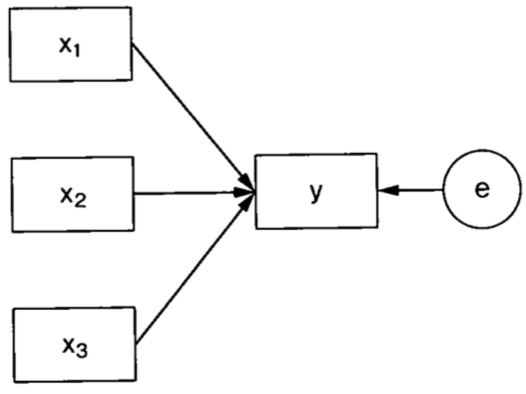

- $y$という応答変数を$x_1,x_2,x_3$という説明変数で説明している．$e$は誤差であり，潜在変数の1つ
- より複雑なパス解析のモデル図

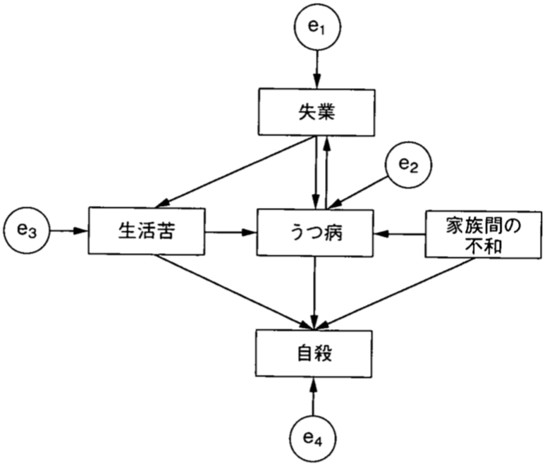

  - 「失業」と「うつ病」の間の双方向の2本の矢印によって，「失業」が「うつ病」を促すと同時に，「うつ病」が「失業」を促す双方向の因果関係を示している．
- 外生変数と内生変数
  - 外生変数：モデルの中で，一度も他の変数の結果になっていない変数．「→」が一度も刺さっていない変数
  - 内生変数：少なくとも一度は他の変数の結果となっている変数．「→」が一度は刺さっている変数
    - 図の場合，$e_1-e_4$の間には相関関係のパスを設定できるが，失業・うつ病・自殺・生活苦の間には設定できない．
- モデルの評価
  - 「適合度」という指標を用いて検討できる．
  - 一般的な検定：「帰無仮説が棄却される」ことが目的
  - パス解析・構造方程式モデリングでの$\chi^2$検定：「帰無仮説が棄却されない」ことが目的
  - 仮説を作って，モデルを作ってから分析へ
- パス解析時の注意
  - データは標準化して解釈することが多い
    - すべての変数の分散を1に揃える，
- この先：
  - （確証的）因子分析とパス解析をあわせた「構造方程式モデリング」を行うことになる．
  - 来週はちょっと変えてそんな感じにしましょう．

### 分析事例：

- 中古車の「乗車年数」「走行距離」「状態」「価格」を一覧にしたデータ

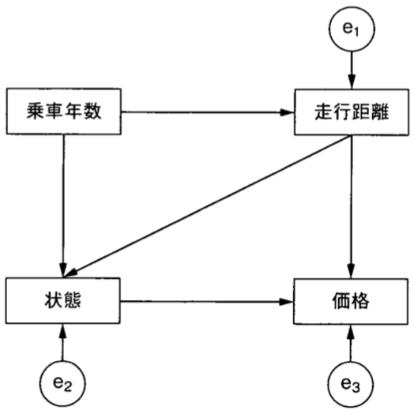

- データを読み込み，「Report」→「Rmd」までを選択する

[コチラからどうぞ](https://akrgt.github.io/2019DA/data/path_analysis1.csv)

- 適宜色々散布図などをプロットして確認しよう．
- 必要なパッケージが入っていないので，インストールする．

```
install.packages("lavaan")
install.packages("semPlot")
```

- 以下のコードを入力する

```r
library(lavaan)
```

```r
library(semPlot)
model1<-'
soko ~ josha
jotai ~ josha + soko
kakaku ~ soko + jotai
'
```

- 図に示したモデルを反映している．
- モデルの計算

```r
result1 <- sem(model1, data = path_analysis1)
```

- 計算結果の出力

```r
summary(result1, standardized=TRUE, fit.measures=TRUE, modindices=TRUE, ci=TRUE)
```

```
## lavaan 0.6-4 ended normally after 81 iterations
##
##   Optimization method                           NLMINB
##   Number of free parameters                          8
##
##   Number of observations                            12
##
##   Estimator                                         ML
##   Model Fit Test Statistic                       0.248
##   Degrees of freedom                                 1
##   P-value (Chi-square)                           0.619
##
## Model test baseline model:
##
##   Minimum Function Test Statistic               95.406
##   Degrees of freedom                                 6
##   P-value                                        0.000
##
## User model versus baseline model:
##
##   Comparative Fit Index (CFI)                    1.000
##   Tucker-Lewis Index (TLI)                       1.050
##
## Loglikelihood and Information Criteria:
##
##   Loglikelihood user model (H0)                -69.036
##   Loglikelihood unrestricted model (H1)        -68.912
##
##   Number of free parameters                          8
##   Akaike (AIC)                                 154.071
##   Bayesian (BIC)                               157.951
##   Sample-size adjusted Bayesian (BIC)          133.759
##
## Root Mean Square Error of Approximation:
##
##   RMSEA                                          0.000
##   90 Percent Confidence Interval          0.000  0.606
##   P-value RMSEA <= 0.05                          0.624
##
## Standardized Root Mean Square Residual:
```

[output cut: 33 more lines]

```
##    .kakaku           45.462   18.560    2.449    0.014    9.086   81.839
##    Std.lv  Std.all
##     0.348    0.041
##     1.261    0.202
##    45.462    0.043
##
## Modification Indices:
##
##       lhs op    rhs    mi     epc sepc.lv sepc.all sepc.nox
## 11   soko ~~ kakaku 0.245  -0.581  -0.581   -0.146   -0.146
## 12  jotai ~~ kakaku 0.245 -24.848 -24.848   -3.282   -3.282
## 14   soko  ~ kakaku 0.245  -0.013  -0.013   -0.142   -0.142
## 15  jotai  ~ kakaku 0.245  -0.547  -0.547   -7.080   -7.080
## 16 kakaku  ~  josha 0.245   1.593   1.593    0.147    0.049
## 19  josha  ~ kakaku 0.245   0.312   0.312    3.388    3.388
```

- standardized：標準化係数を示す
- fit.measures：適合度指標を出力する
- modindices：修正指標を出力する
- ci：(95%)信頼区間

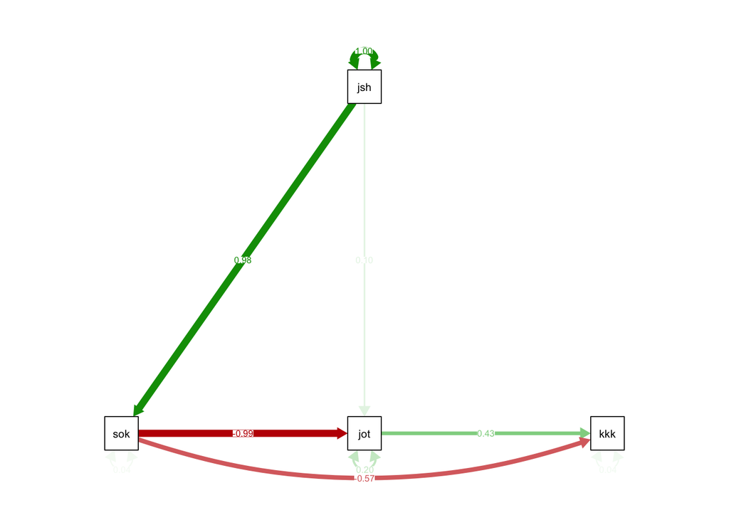

```r
semPaths(result1, "std", title = FALSE)
```

- 適合度指標がほとんど良好な値
  - 有意でないパス（乗車年数→状態）を削除する．
    - 薄緑色のパス
  - もう一回分析をしてみる．

```r
model2<-'
soko ~ josha
jotai ~  soko
kakaku ~ soko + jotai
'
```

```r
result2 <- sem(model2, data = path_analysis1)
```

- 計算結果の出力

```r
summary(result2, standardized=TRUE, fit.measures=TRUE, modindices=TRUE, ci=TRUE)
```

```
## lavaan 0.6-4 ended normally after 42 iterations
##
##   Optimization method                           NLMINB
##   Number of free parameters                          7
##
##   Number of observations                            12
##
##   Estimator                                         ML
##   Model Fit Test Statistic                       0.271
##   Degrees of freedom                                 2
##   P-value (Chi-square)                           0.873
##
## Model test baseline model:
##
##   Minimum Function Test Statistic               95.406
##   Degrees of freedom                                 6
##   P-value                                        0.000
##
## User model versus baseline model:
##
##   Comparative Fit Index (CFI)                    1.000
##   Tucker-Lewis Index (TLI)                       1.058
##
## Loglikelihood and Information Criteria:
##
##   Loglikelihood user model (H0)                -69.047
##   Loglikelihood unrestricted model (H1)        -68.912
##
##   Number of free parameters                          7
##   Akaike (AIC)                                 152.094
##   Bayesian (BIC)                               155.488
##   Sample-size adjusted Bayesian (BIC)          134.321
##
## Root Mean Square Error of Approximation:
##
##   RMSEA                                          0.000
##   90 Percent Confidence Interval          0.000  0.288
##   P-value RMSEA <= 0.05                          0.877
##
## Standardized Root Mean Square Residual:
```

[output cut: 33 more lines]

```
##     0.348    0.041
##     1.263    0.202
##    45.462    0.043
##
## Modification Indices:
##
##       lhs op    rhs    mi    epc sepc.lv sepc.all sepc.nox
## 9    soko ~~  jotai 0.023 -0.029  -0.029   -0.044   -0.044
## 10   soko ~~ kakaku 0.245 -0.580  -0.580   -0.146   -0.146
## 12   soko  ~  jotai 0.023 -0.023  -0.023   -0.020   -0.020
## 13   soko  ~ kakaku 0.215 -0.009  -0.009   -0.097   -0.097
## 15  jotai  ~  josha 0.023  0.081   0.081    0.097    0.032
## 16 kakaku  ~  josha 0.245  1.590   1.590    0.147    0.049
## 18  josha  ~  jotai 0.023  0.570   0.570    0.478    0.478
## 19  josha  ~ kakaku 0.215  0.213   0.213    2.313    2.313
```

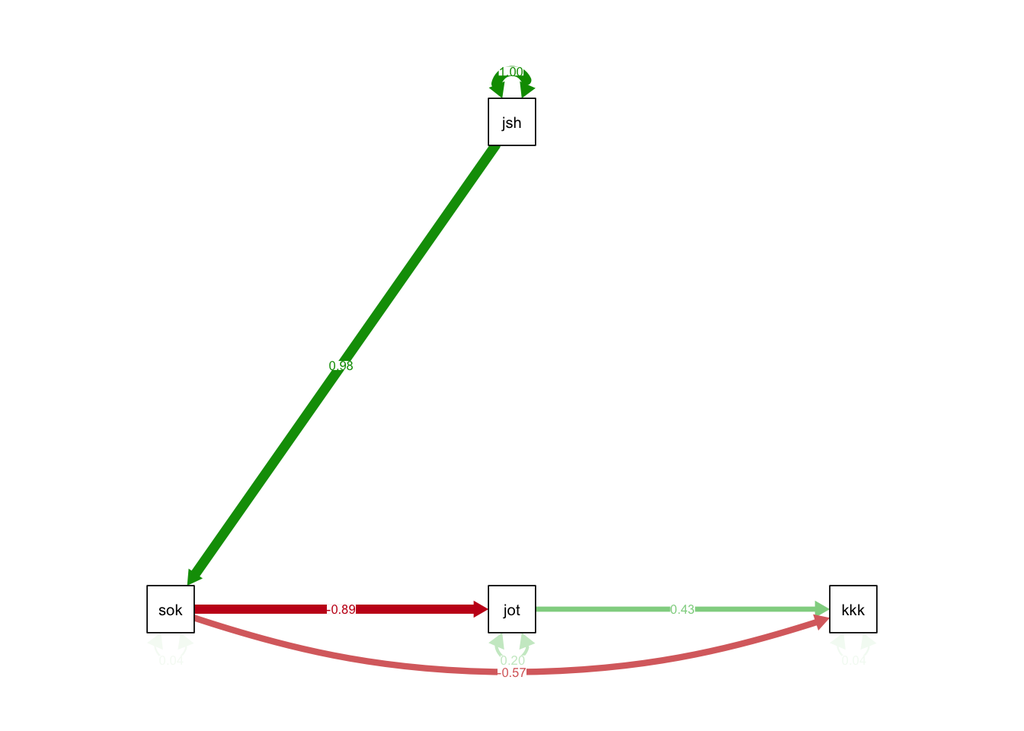

```r
semPaths(result2, "std", title = FALSE)
```

- モデル1とモデル2のAICを比べると2の方が良いので，モデル2をより良いモデルだと扱います． 参考資料：[小杉考司, 清水裕士, 2014,『M-plusとRによる構造方程式モデリング入門』](https://www.amazon.co.jp/dp/4762828254/)

## 構造方程式モデリングに触れてみよう

### 構造方程式モデリングとは？

#### 変数の分類

- 観測変数か潜在変数か
  - 観測変数：実際に観察されている変数
  - 潜在変数：実際には観察し得ない変数
- 構造変数か誤差変数か
  - 構造変数：考察の対象となっている影響関係に，直接・間接的に影響を及ぼす変数
    - 観測変数や潜在変数はいずれも構造変数の1つ
  - 誤差変数：影響関係では説明できない変数．
- 外生変数か内生変数か
  - 外生変数：モデルの中で1度も他の変数の結果にならない変数
  - 内生変数：少なくとも一度は他の変数の結果になる変数

#### 方程式の種類

- 測定方程式：構成概念が複数の観測変数に影響を与えている様子を記述する方程式
  - 構成概念が観測変数によってどのように測定されているかを示す

```
観測変数=係数1*構成概念1 + 係数2*構成概念2+....+誤差
```

- 構造方程式：変数間の影響関係を表現するための式
  - 構成概念→構成概念：構成概念が他の構成概念の原因となる
  - 観測変数→観測変数：観測変数が他の観測変数の原因となる
    - 普通の回帰分析と一致
  - 観測変数→構成概念：観測変数が構成概念の原因となる

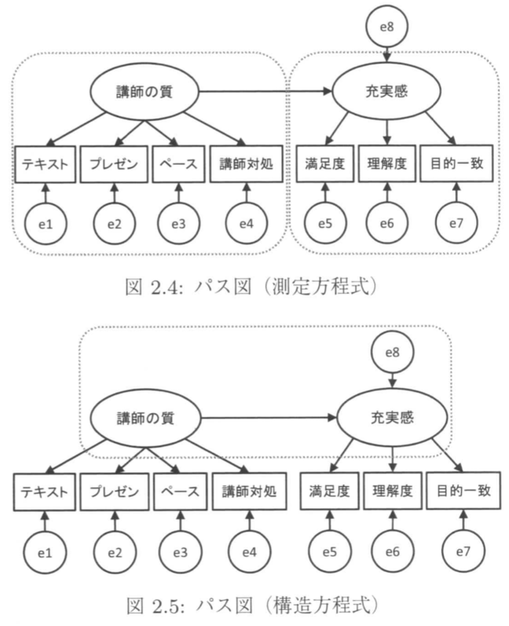

### 例題：セミナーにおける充実感と講師の質に関する関係性を分析する

**seminar.csv**

```r
library(DT)
library(readr)
seminar <- read_csv("/Users/akira/Dropbox/Education/2019MEIJI/[3_Wed2]Data_Analytics/analysis/data/seminar.csv")
DT::datatable(seminar)
```

|  | No | x1 | x2 | x3 | x4 | x5 | x6 | x7 |
| --- | --- | --- | --- | --- | --- | --- | --- | --- |
| 1 | 1 | 3 | 5 | 4 | 5 | 5 | 5 | 4 |
| 2 | 2 | 4 | 4 | 4 | 5 | 3 | 4 | 2 |
| 3 | 3 | 4 | 4 | 4 | 4 | 5 | 4 | 1 |
| 4 | 4 | 2 | 3 | 2 | 2 | 4 | 2 | 4 |
| 5 | 5 | 1 | 1 | 1 | 1 | 1 | 1 | 1 |
| 6 | 6 | 3 | 4 | 4 | 4 | 2 | 4 | 2 |
| 7 | 7 | 4 | 4 | 3 | 2 | 1 | 4 | 2 |
| 8 | 8 | 4 | 4 | 4 | 4 | 4 | 4 | 2 |
| 9 | 9 | 5 | 5 | 5 | 5 | 1 | 1 | 1 |
| 10 | 10 | 4 | 4 | 3 | 4 | 4 | 4 | 2 |

[output cut: 108 more lines]

| 変数名 | 名前 |
| --- | --- |
| x1 | テキスト |
| x2 | プレゼン |
| x3 | ペース |
| x4 | 講師対処 |
| x5 | 満足度 |
| x6 | 理解度 |
| x7 | 目的一致 |

- （探索的）因子分析を行う
  - 講師の質：「テキスト」「プレゼン」「ペース」「講師対処」
  - 充実感：「満足度」「理解度」「目的一致」
- 講師の質によって「充実感」を説明できるのではないか？
- 使うパッケージ：
  - lavaanとsemPlot

```r
library(lavaan)
library(semPlot)
```

#### 想定モデル

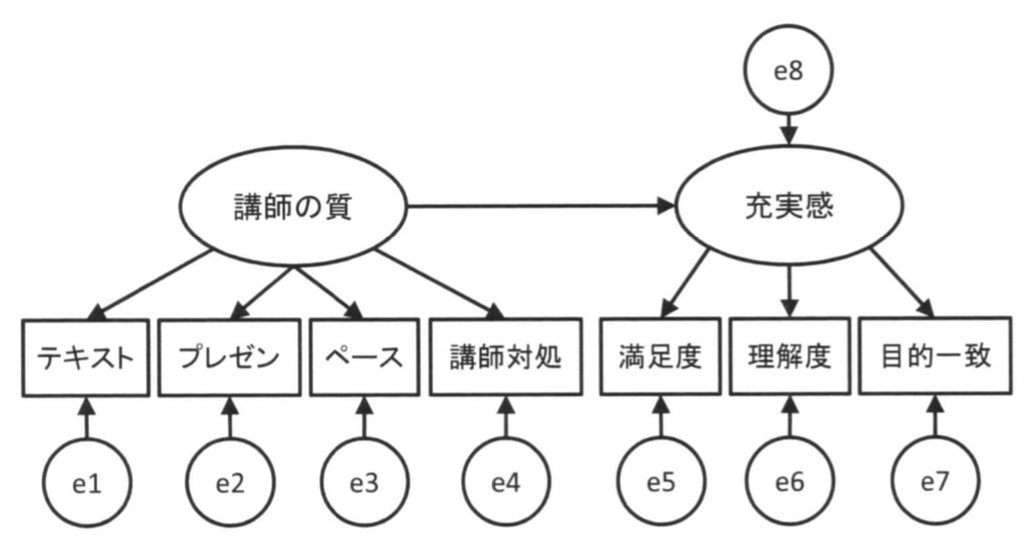

#### 想定モデル式

- 測定方程式：`=~`の左側には構成概念を，右側には観測変数を配置する．

```
f1 =~ x1+x2+x3+x4
f2 =~ x5+x6+x7
```

- 測定方程式はフルに書くと下記のとおりだが，実際には上記の簡潔な表現が使われる

```
f1 =~ x1
f1 =~ x2
f1 =~ x3
f1 =~ x4

f2 =~ x5
f2 =~ x6
f2 =~ x7
```

- 構造方程式：`~`の左には内生変数（応答変数）を，右側には外生変数（説明変数）を配置する．

```
f2 ~ f1
```

- 共変関係：それぞれの変数間に存在する相関関係も考慮できる．下記のように記述できるが，実際には自動的に考慮するようになっているが，誤差変数と外生的な構造変数には共変関係が仮定されないため，設定が必要．

```
x2 ~~ x4
```

- 以上をまとめてモデルオブジェクトに代入する

```r
model1<-'
f1 =~ x1+x2+x3+x4
f2 =~ x5+x6+x7
f2 ~ f1
'
```

#### データを読んで分析を行う

```r
fit1 <- sem(model1, seminar, "ML")
fit1
```

```
## lavaan 0.6-4 ended normally after 47 iterations
##
##   Optimization method                           NLMINB
##   Number of free parameters                         22
##
##   Number of observations                           118
##
##   Estimator                                       DWLS      Robust
##   Model Fit Test Statistic                       6.740      12.068
##   Degrees of freedom                                13          13
##   P-value (Chi-square)                           0.915       0.522
##   Scaling correction factor                                  0.714
##   Shift parameter                                            2.622
##     for simple second-order correction (Mplus variant)
```

```r
summary(fit1)
```

```
## lavaan 0.6-4 ended normally after 47 iterations
##
##   Optimization method                           NLMINB
##   Number of free parameters                         22
##
##   Number of observations                           118
##
##   Estimator                                       DWLS      Robust
##   Model Fit Test Statistic                       6.740      12.068
##   Degrees of freedom                                13          13
##   P-value (Chi-square)                           0.915       0.522
##   Scaling correction factor                                  0.714
##   Shift parameter                                            2.622
##     for simple second-order correction (Mplus variant)
##
## Parameter Estimates:
##
##   Information                                 Expected
##   Information saturated (h1) model        Unstructured
##   Standard Errors                           Robust.sem
##
## Latent Variables:
##                    Estimate  Std.Err  z-value  P(>|z|)
##   f1 =~
##     x1                1.000
##     x2                1.993    0.861    2.316    0.021
##     x3                1.447    0.531    2.726    0.006
##     x4                1.529    0.588    2.601    0.009
##   f2 =~
##     x5                1.000
##     x6                0.663    0.276    2.403    0.016
##     x7                0.363    0.180    2.017    0.044
##
## Regressions:
##                    Estimate  Std.Err  z-value  P(>|z|)
##   f2 ~
##     f1                1.162    0.761    1.528    0.127
##
## Intercepts:
##                    Estimate  Std.Err  z-value  P(>|z|)
##    .x1                3.619    0.095   38.208    0.000
##    .x2                3.602    0.084   43.129    0.000
##    .x3                3.153    0.110   28.642    0.000
##    .x4                4.220    0.104   40.452    0.000
##    .x5                3.085    0.131   23.636    0.000
##    .x6                3.322    0.122   27.212    0.000
##    .x7                1.627    0.085   19.157    0.000
##     f1                0.000
##    .f2                0.000
##
## Variances:
##                    Estimate  Std.Err  z-value  P(>|z|)
##    .x1                0.923    0.166    5.562    0.000
##    .x2                0.284    0.150    1.888    0.059
##    .x3                1.146    0.149    7.713    0.000
##    .x4                0.967    0.190    5.095    0.000
##    .x5                1.195    0.400    2.989    0.003
##    .x6                1.401    0.228    6.147    0.000
##    .x7                0.744    0.150    4.973    0.000
##     f1                0.136    0.107    1.274    0.203
##    .f2                0.632    0.484    1.305    0.192
```

#### 構造方程式モデリングのメリット：

- 柔軟にモデル公正ができる
- しかし，データが少なすぎると十分な分析ができない．

#### モデルの評価：

```r
summary(fit1, fit.measure=TRUE)
```

```
## lavaan 0.6-4 ended normally after 47 iterations
##
##   Optimization method                           NLMINB
##   Number of free parameters                         22
##
##   Number of observations                           118
##
##   Estimator                                       DWLS      Robust
##   Model Fit Test Statistic                       6.740      12.068
##   Degrees of freedom                                13          13
##   P-value (Chi-square)                           0.915       0.522
##   Scaling correction factor                                  0.714
##   Shift parameter                                            2.622
##     for simple second-order correction (Mplus variant)
```

```
##
## Model test baseline model:
##
##   Minimum Function Test Statistic               78.723      56.323
##   Degrees of freedom                                21          21
##   P-value                                        0.000       0.000
##
## User model versus baseline model:
##
##   Comparative Fit Index (CFI)                    1.000       1.000
##   Tucker-Lewis Index (TLI)                       1.175       1.043
##
##   Robust Comparative Fit Index (CFI)                            NA
##   Robust Tucker-Lewis Index (TLI)                               NA
##
## Root Mean Square Error of Approximation:
##
##   RMSEA                                          0.000       0.000
##   90 Percent Confidence Interval          0.000  0.034       0.000  0.086
##   P-value RMSEA <= 0.05                          0.973       0.755
##
##   Robust RMSEA                                                  NA
##   90 Percent Confidence Interval                             0.000     NA
##
## Standardized Root Mean Square Residual:
##
##   SRMR                                           0.049       0.049
##
## Parameter Estimates:
##
##   Information                                 Expected
##   Information saturated (h1) model        Unstructured
##   Standard Errors                           Robust.sem
##
## Latent Variables:
##                    Estimate  Std.Err  z-value  P(>|z|)
##   f1 =~
##     x1                1.000
##     x2                1.993    0.861    2.316    0.021
##     x3                1.447    0.531    2.726    0.006
```

[output cut: 19 more lines]

```
##    .x7                1.627    0.085   19.157    0.000
##     f1                0.000
##    .f2                0.000
##
## Variances:
##                    Estimate  Std.Err  z-value  P(>|z|)
##    .x1                0.923    0.166    5.562    0.000
##    .x2                0.284    0.150    1.888    0.059
##    .x3                1.146    0.149    7.713    0.000
##    .x4                0.967    0.190    5.095    0.000
##    .x5                1.195    0.400    2.989    0.003
##    .x6                1.401    0.228    6.147    0.000
##    .x7                0.744    0.150    4.973    0.000
##     f1                0.136    0.107    1.274    0.203
##    .f2                0.632    0.484    1.305    0.192
```

- $\chi^2$値：帰無仮説が採択されるとよいが，データが多すぎると有意になりがち．
  - これだけで評価してはいけない
- CFI(Comparative Fit Index，比較適合度指標)：0-1の間の数値を取る指標，1に近いほど当てはまりがよく，0.95以上あれば良いモデル．
  - TLI(Tucker-Lewis Index)も1に近いほど当てはまりが良いが，1を超えることもある
  - RMSEA：0.05以下であれば当てはまりがよく，0.1以上であれば当てはまりが悪い．
  - SRMR(Standardized Root Mean Square Residual，標準化残差平方平均)：標本の分散，共分散とモデルにより再現される分散・共分散の差である残差によってモデル適合を検討する指標．0に近いほど当てはまっている．

#### モデルの出力

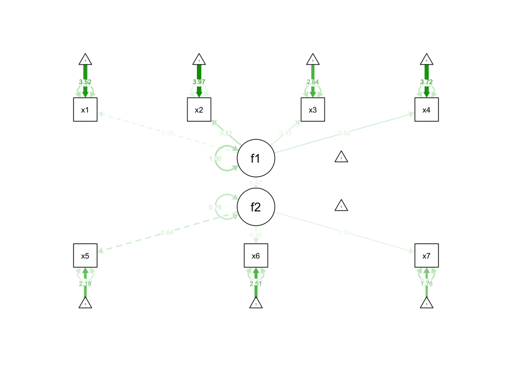

```r
semPaths(fit1, "std", title = FALSE)
```

#### 分析結果の解釈

- 2種類の母数推定
  - 非標準化推定値：データを標準化せずに分析を行った際に得られる推定値，変数単位の影響を受ける．
  - 標準化推定値：データを標準化して分析を行った際に得られる推定値，すべての構造変数が標準化されているので，単位の影響を受けない．
    - 「構成概念」を扱うときには非標準化推定値の解釈が難しいために，標準化推定値を報告することが多い
- 非標準化推定値の算出(信頼区間も)

```r
parameterestimates(fit1)
```

```
##    lhs op rhs   est    se      z pvalue ci.lower ci.upper
## 1   f1 =~  x1 1.000 0.000     NA     NA    1.000    1.000
## 2   f1 =~  x2 1.993 0.861  2.316  0.021    0.306    3.679
## 3   f1 =~  x3 1.447 0.531  2.726  0.006    0.406    2.487
## 4   f1 =~  x4 1.529 0.588  2.601  0.009    0.377    2.681
## 5   f2 =~  x5 1.000 0.000     NA     NA    1.000    1.000
## 6   f2 =~  x6 0.663 0.276  2.403  0.016    0.122    1.203
## 7   f2 =~  x7 0.363 0.180  2.017  0.044    0.010    0.717
## 8   f2  ~  f1 1.162 0.761  1.528  0.127   -0.329    2.653
## 9   x1 ~~  x1 0.923 0.166  5.562  0.000    0.598    1.248
## 10  x2 ~~  x2 0.284 0.150  1.888  0.059   -0.011    0.579
## 11  x3 ~~  x3 1.146 0.149  7.713  0.000    0.854    1.437
## 12  x4 ~~  x4 0.967 0.190  5.095  0.000    0.595    1.339
## 13  x5 ~~  x5 1.195 0.400  2.989  0.003    0.411    1.978
## 14  x6 ~~  x6 1.401 0.228  6.147  0.000    0.954    1.848
## 15  x7 ~~  x7 0.744 0.150  4.973  0.000    0.451    1.037
## 16  f1 ~~  f1 0.136 0.107  1.274  0.203   -0.073    0.344
## 17  f2 ~~  f2 0.632 0.484  1.305  0.192   -0.317    1.580
## 18  x1 ~1     3.619 0.095 38.208  0.000    3.433    3.804
## 19  x2 ~1     3.602 0.084 43.129  0.000    3.438    3.765
## 20  x3 ~1     3.153 0.110 28.642  0.000    2.937    3.368
## 21  x4 ~1     4.220 0.104 40.452  0.000    4.016    4.425
## 22  x5 ~1     3.085 0.131 23.636  0.000    2.829    3.341
## 23  x6 ~1     3.322 0.122 27.212  0.000    3.083    3.561
## 24  x7 ~1     1.627 0.085 19.157  0.000    1.461    1.794
## 25  f1 ~1     0.000 0.000     NA     NA    0.000    0.000
## 26  f2 ~1     0.000 0.000     NA     NA    0.000    0.000
```

- 標準化推定値の算出

```r
standardizedsolution(fit1)
```

```
##    lhs op rhs est.std    se      z pvalue ci.lower ci.upper
## 1   f1 =~  x1   0.358 0.137  2.607  0.009    0.089    0.627
## 2   f1 =~  x2   0.809 0.117  6.888  0.000    0.579    1.039
## 3   f1 =~  x3   0.446 0.102  4.358  0.000    0.245    0.646
## 4   f1 =~  x4   0.497 0.102  4.872  0.000    0.297    0.697
## 5   f2 =~  x5   0.637 0.159  3.999  0.000    0.325    0.949
## 6   f2 =~  x6   0.451 0.132  3.418  0.001    0.192    0.710
## 7   f2 =~  x7   0.356 0.117  3.047  0.002    0.127    0.584
## 8   f2  ~  f1   0.474 0.273  1.739  0.082   -0.060    1.009
## 9   x1 ~~  x1   0.872 0.098  8.866  0.000    0.679    1.065
## 10  x2 ~~  x2   0.345 0.190  1.816  0.069   -0.027    0.718
## 11  x3 ~~  x3   0.801 0.091  8.790  0.000    0.623    0.980
## 12  x4 ~~  x4   0.753 0.101  7.427  0.000    0.554    0.952
## 13  x5 ~~  x5   0.595 0.203  2.932  0.003    0.197    0.992
## 14  x6 ~~  x6   0.797 0.119  6.693  0.000    0.563    1.030
## 15  x7 ~~  x7   0.874 0.083 10.527  0.000    0.711    1.036
## 16  f1 ~~  f1   1.000 0.000     NA     NA    1.000    1.000
## 17  f2 ~~  f2   0.775 0.259  2.997  0.003    0.268    1.282
## 18  x1 ~1       3.517 0.308 11.435  0.000    2.914    4.120
## 19  x2 ~1       3.970 0.304 13.047  0.000    3.374    4.567
## 20  x3 ~1       2.637 0.186 14.194  0.000    2.273    3.001
## 21  x4 ~1       3.724 0.416  8.951  0.000    2.909    4.539
## 22  x5 ~1       2.176 0.135 16.149  0.000    1.912    2.440
## 23  x6 ~1       2.505 0.168 14.944  0.000    2.176    2.834
## 24  x7 ~1       1.764 0.117 15.039  0.000    1.534    1.993
## 25  f1 ~1       0.000 0.000     NA     NA    0.000    0.000
## 26  f2 ~1       0.000 0.000     NA     NA    0.000    0.000
```

#### その他の指標

- 構成概念スコア：研究仮説で過程した構成概念の尺度上で，各観測対象がどの程度その特性を持っているのか示した値

```r
predict(fit1)
```

```
##            f1     f2
##   [1,]  0.495  1.535
##   [2,]  0.209  0.281
##   [3,]  0.179  0.669
##   [4,] -0.366  0.215
##   [5,] -1.117 -1.788
##   [6,]  0.094 -0.080
##   [7,] -0.046 -0.456
##   [8,]  0.171  0.544
##   [9,]  0.466 -0.788
##  [10,]  0.125  0.515
##  [11,]  0.132  0.352
##  [12,]  0.425  0.124
##  [13,] -0.953  0.788
##  [14,] -0.529 -1.416
```

[output cut: 104 more lines]

- 散布図を見てみる

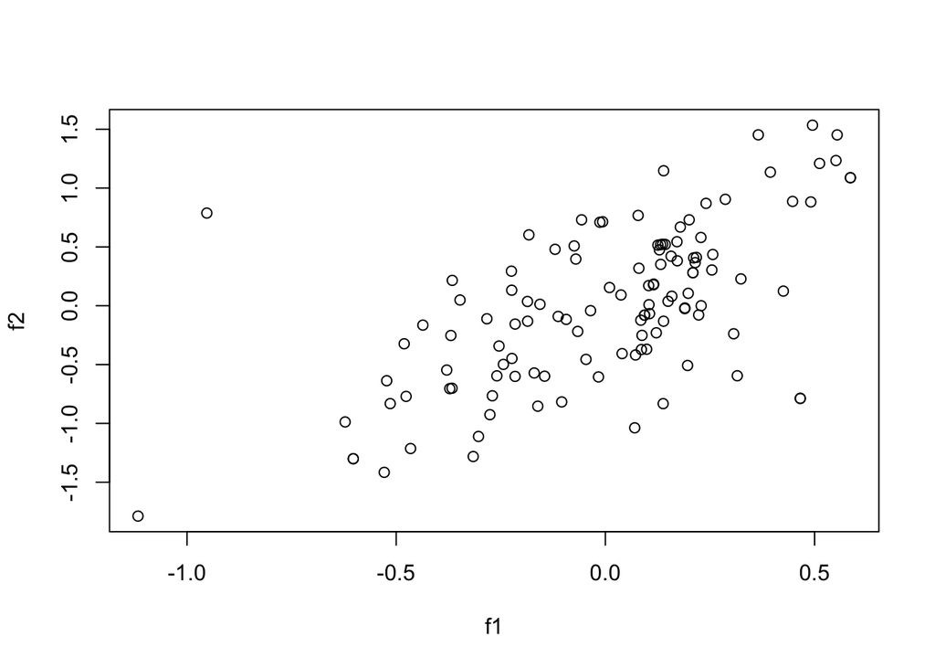

```r
factor_score<-predict(fit1)
plot(factor_score)
```

- 特異値（極値）の人に質問をしていると，その他の要因の影響がわかるかも
  - 講師の質以外に充実感に影響を与える要因がわかるかも

#### レポートでまとめる時に書くべきこと

- 構成概念に関する定義
- 観測変数の内容
- パス図
- 観測対象数，観測変数の数
- 推定方法
- ソフトウェア
- 標準化推定値
- 適合度(CFI，RMSEAなど)
- 母数の検定・標準誤差・信頼区間

# 資料

## 演習問題：

#### 1. 以下のデータについて，分析を行ってください．

### データの概要

- 今回扱うデータ：クラウドソーシングを用いた意思決定に関するデータの一部
  - 現在分析中のデータなので，あまり外部に流出しないように気をつけてください．

**[factanal](https://akrgt.github.io/2019DA/data/factanal.csv)**

```r
library(DT)
library(readr)
factanal <- read_csv("/Users/akira/Dropbox/Education/2019MEIJI/[3_Wed2]Data_Analytics/analysis/data/factanal.csv")
DT::datatable(factanal)
```

|  | ID | ratemo_1 | ratemo_2 | ratemo_3 | ratemo_4 | ratemo_5 | ratemo_6 | ratemo_7 | ratemo_8 | ratemo_9 | ratemo_10 | ratemo_11 | ratemo_12 | ratemo_13 | ratemo_14 | ratemo_15 | ratemo_16 | ratemo_17 | ratemo_18 | ratemo_19 | ratemo_20 | ratemo_21 | ratemo_22 | ratemo_23 | ratemo_24 | big5_1 | big5_2 | big5_3 | big5_4 | … |
| --- | --- | --- | --- | --- | --- | --- | --- | --- | --- | --- | --- | --- | --- | --- | --- | --- | --- | --- | --- | --- | --- | --- | --- | --- | --- | --- | --- | --- | --- | --- |
| 1 | mxd1gnfm | 2 | 3 | 3 | 3 | 2 | 3 | 2 | 3 | 4 | 2 | 4 | 3 | 3 | 3 | 4 | 2 | 3 | 3 | 3 | 2 | 3 | 3 | 3 | 4 | 3 | 3 | 5 | 5 | … |
| 2 | qeh267wp | 3 | 4 | 4 | 4 | 2 | 2 | 3 | 2 | 5 | 1 | 3 | 5 | 2 | 3 | 4 | 4 | 5 | 5 | 2 | 4 | 2 | 2 | 2 | 2 | 2 | 3 | 2 | 7 | … |
| 3 | j9wl4uzq | 4 | 3 | 4 | 3 | 3 | 2 | 4 | 3 | 3 | 4 | 4 | 3 | 4 | 4 | 4 | 3 | 3 | 3 | 4 | 3 | 2 | 4 | 3 | 3 | 2 | 2 | 1 | 6 | … |
| 4 | xz0fmbgj | 1 | 2 | 4 | 2 | 4 | 1 | 4 | 5 | 1 | 4 | 5 | 1 | 4 | 5 | 4 | 4 | 2 | 1 | 5 | 2 | 4 | 5 | 4 | 2 | 4 | 2 | 5 | 2 | … |
| 5 | xovlpk27 | 4 | 4 | 5 | 4 | 2 | 2 | 5 | 2 | 2 | 1 | 5 | 2 | 4 | 4 | 2 | 4 | 2 | 2 | 4 | 4 | 2 | 4 | 5 | 2 | 6 | 5 | 5 | 2 | … |
| 6 | 5yx2r16l | 3 | 3 | 4 | 3 | 2 | 3 | 3 | 2 | 3 | 2 | 3 | 3 | 3 | 4 | 3 | 3 | 3 | 2 | 4 | 4 | 3 | 3 | 3 | 2 | 1 | 2 | 3 | 5 | … |
| 7 | f26gjc89 | 4 | 3 | 3 | 3 | 3 | 3 | 3 | 3 | 1 | 3 | 3 | 3 | 3 | 3 | 2 | 3 | 3 | 3 | 3 | 3 | 3 | 3 | 3 | 3 | 7 | 1 | 4 | 4 | … |
| 8 | 8tshve4p | 4 | 2 | 4 | 4 | 2 | 2 | 3 | 2 | 2 | 2 | 3 | 3 | 3 | 4 | 2 | 4 | 3 | 3 | 3 | 3 | 3 | 3 | 2 | 2 | 6 | 3 | 6 | 3 | … |
| 9 | bjvdwhw1 | 1 | 1 | 2 | 3 | 2 | 1 | 3 | 2 | 4 | 3 | 3 | 2 | 2 | 3 | 4 | 1 | 2 | 4 | 2 | 2 | 3 | 3 | 3 | 5 | 1 | 3 | 4 | 5 | … |
| 10 | 1j6a9lfb | 4 | 4 | 3 | 4 | 2 | 4 | 3 | 1 | 2 | 2 | 3 | 4 | 3 | 4 | 2 | 5 | 4 | 4 | 3 | 4 | 2 | 3 | 2 | 2 | 5 | 5 | 3 | 5 | … |

[output cut: 784 more lines]

この中から，ratemo_1からratemo_24までのデータを分析する．

- REI日本語版：情報処理スタイル尺度，直観的処理と合理的処理における個人差を明らかにする尺度（内藤et.al, 2004）
  - Epstein et. al（1996）のREI(Rational Experiential Inventory)の日本語版
- 短縮版を採用
- 直観・感情的な反応を示すシステム1と論理・理性的な思考をもたらすシステム2を反映
  - Kahneman, 2012; Evans, 2010
- **[参考資料①](https://www.jstage.jst.go.jp/article/personality/13/1/13_1_67/_pdf/-char/ja)**

| 逆転項目 | 短縮版 | 順番 | 項目 |
| --- | --- | --- | --- |
|  | ＊ | 1 | たいていの人より，ものごとを論理的に解決するのが上手である． |
| ＊ | ＊ | 2 | 直観に頼らなければならない状況は好きではない． |
|  | ＊ | 3 | 自分の予感を信じることにしている． |
|  | ＊ | 4 | 論理的な考えの持ち主だ． |
| ＊ | ＊ | 5 | ものごとを注意深く理論的に解決するのは，得意ではない． |
|  | ＊ | 6 | 簡単な問題より複雑な問題の方が好きだ． |
|  | ＊ | 7 | なぜだか理由を説明できないが，その人が正しいか間違っているかを，感じとることができる． |
| ＊ | ＊ | 8 | 分析的に考える方ではない． |
| ＊ | ＊ | 9 | 私にはすごい直観力はない． |
| ＊ | ＊ | 10 | 考えることは，楽しいことだと思わない． |
|  | ＊ | 11 | 直観は問題を解決するのに役立つ方法だろう． |
| ＊ | ＊ | 12 | 感情に基づいて重要な決定をするのは，愚かなことだと思う． |
|  | ＊ | 13 | 行動を決める時，直観に頼ることが多い． |
|  | ＊ | 14 | 私にとって，新しい考え方を学ぶことは，とても魅力的である． |
| ＊ | ＊ | 15 | 複雑な問題を解決するのは，得意ではない． |
|  | ＊ | 16 | 知的な挑戦が好きだ． |
| ＊ | ＊ | 17 | 直観に頼って重要な決定をするのは，いい考えだと思わない． |
| ＊ | ＊ | 18 | もし私が直観に頼るならば，間違いをおかすことが多くなるだろう． |
|  | ＊ | 19 | 直観的な印象に頼るのが好きだ． |
|  | ＊ | 20 | 一生懸命考えなければならないような問題を解決するのが好きだ． |
|  | ＊ | 21 | 答えを見つけるために直観に従って，うまくいかなかったことはほとんどない． |
|  | ＊ | 22 | 人生や生活上のいろんな問題を考えるとき，直観的にやるとうまくいく． |
| ＊ | ＊ | 23 | 注意深く論理的な分析が必要とされる問題を解決するのは，得意ではない． |
| ＊ | ＊ | 24 | いろいろ考えるのは好きではない． |

### 逆転項目とは

- 逆転項目：他の質問項目とは違い，測定の向きが逆であるデータ．
  - 因子分析を行う際には，逆転項目は反転させる必要がある．
- 今回の調査では：
  - 「1 ：全くあてはまらない」「2 ：あまりあてはまらない」「3 ：どちらともいえない」「4 ：少しあてはまる」「5 ：非常にあてはまる」
  - 逆転項目については1→5，2→4，3→3，4→2，5→1に置き換える必要がある．
  - 該当項目については6からそれぞれの値を引いてあげれば良い．

### 実践してみよう

#### 逆転項目に対応しよう

- Transform→Transformation type:をcreateに設定

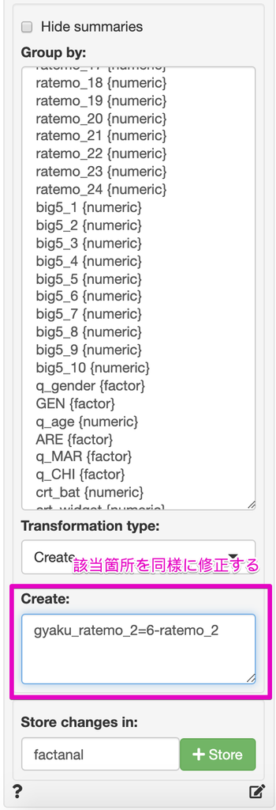

- これで一個一個やっていったら少しめんどくさいため，コピペをしてReport→Rmdを選んだほうが良い．
  - そのまま一気に複数作ってしまったほうが楽．

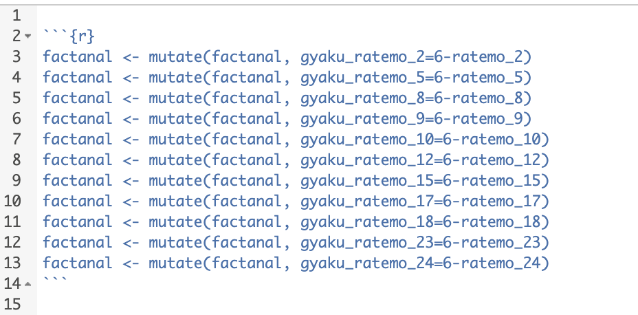

```r
library(readr)
factanal <- read_csv("../data/factanal.csv")
library(dplyr)
factanal <- mutate(factanal, gyaku_ratemo_2=6-ratemo_2)
factanal <- mutate(factanal, gyaku_ratemo_5=6-ratemo_5)
factanal <- mutate(factanal, gyaku_ratemo_8=6-ratemo_8)
factanal <- mutate(factanal, gyaku_ratemo_9=6-ratemo_9)
factanal <- mutate(factanal, gyaku_ratemo_10=6-ratemo_10)
factanal <- mutate(factanal, gyaku_ratemo_12=6-ratemo_12)
factanal <- mutate(factanal, gyaku_ratemo_15=6-ratemo_15)
factanal <- mutate(factanal, gyaku_ratemo_17=6-ratemo_17)
factanal <- mutate(factanal, gyaku_ratemo_18=6-ratemo_18)
factanal <- mutate(factanal, gyaku_ratemo_23=6-ratemo_23)
factanal <- mutate(factanal, gyaku_ratemo_24=6-ratemo_24)
```

1. 構造方程式モデリングを用いて，システム1とシステム2が以下に与える影響について分析をしてください． 1.1. 第2者被監視感情(crt_2nd) 1.2. 第3者被監視感情(crt_3rd) 1.3. 超自然的存在被監視感情(crt_sup)

##### データの頭10個

```r
library(DT)
library(readr)
exdataset <- read_csv("/Users/akira/Dropbox/Education/2019MEIJI/[3_Wed2]Data_Analytics/analysis/data/exdataset.csv")
DT::datatable(exdataset)
```

|  | SUB_HAP | SUB_SAT | SUB_SLP | DIC_PAR | DIC_FRI | DIC_OTH | ULT_PRO_PAR | ULT_PRO_FRI | ULT_PRO_OTH | ULT_REC_PAR | ULT_REC_FRI | ULT_REC_OTH | TRU_PAR | TRU_FRI | TRU_OTH | SPN_UNM | SPN_THK | SPN_FEA | SPN_LIV | SPN_IMP | KAN_SEC | KAN_THI | KAN_SUP | KAN_PRD | KAN_KYK | DED_SHI | DED_TEN | DED_JIG | DED_KIS | … |
| --- | --- | --- | --- | --- | --- | --- | --- | --- | --- | --- | --- | --- | --- | --- | --- | --- | --- | --- | --- | --- | --- | --- | --- | --- | --- | --- | --- | --- | --- | --- |
| 1 | 4 | 4 | 9 | 10 | 5 | 3 | 10 | 5 | 5 | 0 | 1 | 1 | 10 | 5 | 3 | 1 | 3 | 3 | 3 | 4 | 1 | 2 | 1 | 2 | 3 | 1 | 1 | 1 | 3 | … |
| 2 | 6 | 5 | 8 | 3 | 1 | 0 | 3 | 5 | 7 | 3 | 5 | 5 | 2 | 1 | 0 | 2 | 3 | 3 | 2 | 3 | 3 | 3 | 2 | 2 | 3 | 2 | 2 | 2 | 3 | … |
| 3 | 5 | 3 | 3 | 10 | 5 | 0 | 10 | 5 | 0 | 10 | 5 | 0 | 10 | 5 | 0 | 2 | 3 | 3 | 2 | 3 | 3 | 3 | 3 | 2 | 2 | 3 | 2 | 2 | 3 | … |
| 4 | 5 | 5 | 4 | 2 | 0 | 0 | 5 | 5 | 5 | 5 | 5 | 5 | 2 | 2 | 2 | 4 | 3 | 3 | 3 | 3 | 2 | 2 | 4 | 4 | 3 | 2 | 2 | 2 | 3 | … |
| 5 | 3 | 3 | 2 | 0 | 0 | 0 | 5 | 5 | 0 | 5 | 5 | 0 | 10 | 10 | 1 | 1 | 2 | 3 | 3 | 3 | 1 | 1 | 1 | 1 | 3 | 4 | 4 | 4 | 2 | … |
| 6 | 7 | 7 | 6 | 3 | 1 | 0 | 3 | 1 | 0 | 3 | 1 | 0 | 5 | 3 | 0 | 3 | 3 | 3 | 3 | 3 | 3 | 3 | 2 | 3 | 3 | 3 | 3 | 3 | 3 | … |
| 7 | 5 | 5 | 6 | 5 | 2 | 0 | 5 | 3 | 2 | 0 | 1 | 1 | 10 | 5 | 0 | 2 | 2 | 2 | 2 | 3 | 3 | 3 | 1 | 3 | 4 | 4 | 2 | 4 | 2 | … |
| 8 | 5 | 5 | 8 | 5 | 5 | 0 | 5 | 5 | 0 | 5 | 5 | 0 | 5 | 8 | 0 | 4 | 4 | 4 | 4 | 3 | 4 | 4 | 4 | 3 | 3 | 3 | 3 | 3 | 3 | … |
| 9 | 1 | 3 | 1 | 10 | 5 | 0 | 10 | 5 | 0 | 10 | 5 | 0 | 10 | 8 | 4 | 3 | 4 | 4 | 4 | 4 | 3 | 1 | 1 | 1 | 3 | 3 | 3 | 3 | 4 | … |
| 10 | 7 | 7 | 5 | 5 | 5 | 0 | 5 | 5 | 5 | 5 | 5 | 0 | 3 | 3 | 0 | 2 | 3 | 3 | 3 | 3 | 2 | 2 | 2 | 2 | 3 | 2 | 2 | 2 | 3 | … |

[output cut: 953 more lines]

##### 主観的指標

| 項目名 | データタイトル | 質問項目 | 回答 |
| --- | --- | --- | --- |
| 主観的幸福度 | SUB_HAP | 現在，あなたはどの程度幸せですか？「とても幸せ」を10点，「とても不幸せ」を0点とすると，何点くらいになると思いますか？* | 0点「とても不幸せ」-10点「とても幸せ」 |
| 生活満足度 | SUB_SAT | あなたは全体として最近の生活にどの程度満足していますか？「とても満足」を10点，「とても不満足」を0点とすると，何点くらいになると思いますか？ | 0点「とても不満足」-10点「とても満足」 |
| 睡眠満足度 | SUB_SLP | あなたは最近，どの程度眠れていますか？「とても眠れている」を10点，「全く眠れていない」を0点とすると，何点くらいになると思いますか？ | 0点「全く眠れていない」-10点「とても眠れている」 |

##### 監視

以下の質問について4点満点でお答えください．

| 項目名 | データタイトル | 質問項目 | 回答 |
| --- | --- | --- | --- |
| 第2者被監視感 | KAN_SEC | 日常生活の中で，直接誰か（人間）に見られていると思うことがある． | 1全くそう思わない-4非常にそう思う |
| 第3者被監視感 | KAN_THI | 日常生活の中で，監視カメラ等を通じて誰か（人間）に間接的に見られていると思うことがある． | 1全くそう思わない-4非常にそう思う |
| 超自然的被監視感 | KAN_SUP | 日常生活の中で，超自然的な存在に見られていると思うことがある． | 1全くそう思わない-4非常にそう思う |

2. 因子分析によって．第2者被監視感(KAN_SEC)，第3者被監視感(KAN_THI)，超自然的存在被監視感(KAN_SUP)を適切な因子数に整理した上で，構造方程式モデリングを用いて以下の用意にに与える影響を分析してください． 2.1. 主観的幸福度(SUB_HAP) 2.2. 生活満足度(SUB_SAT) 2.3. 睡眠満足度(SUB_SLP)

##### 以下データセットclass_dataには，以前「不確実性下の人間行動」の講義を履修している学生を対象とした調査の結果が入っている．これについて，以下の分析を行うこと

**class_data.csv**

```r
library(DT)
library(readr)
class_data <- read_csv("/Users/akira/Dropbox/Education/2019MEIJI/[3_Wed2]Data_Analytics/analysis/data/class_data.csv")
DT::datatable(class_data)
```

|  | participant.code | participant.label | Trust1_SNS | Trust2_SNS | Trust3_SNS | Trust4_SNS | Trust5_SNS | Trust6_SNS | Trust7_SNS | Trust1_location | Trust2_location | Trust3_location | Trust4_location | Trust5_location | Trust6_location | Trust7_location | Trust1_phistory | Trust2_phistory | Trust3_phistory | Trust4_phistory | Trust5_phistory | Trust6_phistory | Trust7_phistory | Trust1_telcom | Trust2_telcom | Trust3_telcom | Trust4_telcom | Trust5_telcom | Trust6_telcom | … |
| --- | --- | --- | --- | --- | --- | --- | --- | --- | --- | --- | --- | --- | --- | --- | --- | --- | --- | --- | --- | --- | --- | --- | --- | --- | --- | --- | --- | --- | --- | --- |
| 1 | sgjacrnx | 1810160448 | 0 | 0 | 0 | 0 | 5 | 0 | 0 | 0 | 0 | 0 | 0 | 5 | 0 | 0 | 60 | 60 | 60 | 45 | 70 | 20 | 55 | 5 | 10 | 9 | 4 | 16 | 0 | … |
| 2 | 6rnh5qnn | 1810170413 | 60 | 30 | 50 | 60 | 70 | 30 | 50 | 30 | 15 | 30 | 15 | 15 | 0 | 15 | 80 | 40 | 34 | 70 | 34 | 0 | 60 | 60 | 34 | 10 | 40 | 60 | 14 | … |
| 3 | 3pmd5hop | 1810160380 | 0 | 0 | 0 | 0 | 0 | 50 | 0 | 40 | 20 | 0 | 0 | 40 | 0 | 0 | 70 | 0 | 0 | 0 | 0 | 0 | 0 | 0 | 0 | 0 | 0 | 0 | 0 | … |
| 4 | b61psx1g | 1810170102 | 0 | 0 | 0 | 0 | 0 | 0 | 0 | 30 | 27 | 50 | 27 | 44 | 0 | 50 | 20 | 39 | 40 | 9 | 15 | 20 | 40 | 0 | 20 | 30 | 0 | 0 | 0 | … |
| 5 | rlm7hlmq | 1810160459 | 40 | 50 | 36 | 33 | 72 | 0 | 68 | 0 | 26 | 11 | 0 | 22 | 0 | 32 | 17 | 50 | 25 | 66 | 64 | 0 | 50 | 5 | 29 | 15 | 10 | 50 | 0 | … |
| 6 | xohp14u9 | 1810170286 | 0 | 16 | 10 | 50 | 51 | 70 | 10 | 0 | 19 | 50 | 0 | 0 | 0 | 50 | 70 | 50 | 15 | 50 | 71 | 0 | 18 | 0 | 11 | 30 | 40 | 50 | 0 | … |
| 7 | ur36i7l8 | 1810170438 | 0 | 0 | 0 | 0 | 0 | 0 | 0 | 0 | 0 | 0 | 0 | 0 | 0 | 0 | 0 | 0 | 0 | 0 | 0 | 0 | 0 | 0 | 0 | 0 | 0 | 0 | 0 | … |
| 8 | qwwiu5xx | 1810170164 | 30 | 20 | 30 | 20 | 30 | 0 | 30 | 0 | 0 | 0 | 0 | 0 | 0 | 0 | 50 | 30 | 30 | 30 | 40 | 0 | 30 | 0 | 0 | 20 | 0 | 30 | 0 | … |
| 9 | 2izf5r8u | 1810170387 | 0 | 0 | 50 | 0 | 0 | 29 | 20 | 0 | 0 | 50 | 0 | 0 | 0 | 16 | 25 | 50 | 72 | 50 | 77 | 0 | 76 | 0 | 0 | 0 | 0 | 0 | 0 | … |
| 10 | c8gmzche | 1810170439 | 10 | 20 | 60 | 10 | 60 | 0 | 20 | 10 | 50 | 20 | 10 | 60 | 0 | 10 | 33 | 27 | 50 | 50 | 34 | 3 | 1 | 10 | 20 | 20 | 15 | 20 | 10 | … |

[output cut: 172 more lines]

- Trust1_gen：ほとんどの人は基本的に正直である
- Trust2_gen：私は人を信頼するほうである
- Trust3_gen：ほとんどの人は基本的に善良で親切である
- Trust4_gen：ほとんどの人は他人を信頼している
- Trust5_gen：ほとんどの人は信用できる
- 逆転項目なし

3.1 この中には他のデータと同様にシステム1とシステム2に関するデータも入っている．これについて，システム1およびシステム2を外生変数，一般的信頼尺度を内生変数とした分析を行ってください．

## Rでデータを扱う時に注意すべきこと

- 必ず数字／文字は半角で入力する．
- 日本語は使わずにローマ字を使用する．
- コメントアウト（コードではなく，関係ないメモを入れること）をするときは半角の「#」から始める．
- メモする内容は全角でもよい．
- ファイル名およびパスには決して全角の文字（ひらがな，カタカナ，漢字，全角スペースなど）を入れてはいけない．
- 半角英数字だけにする．
- 慌てずに落ち着いて操作すれば，決して難しくない．
- 1つずつ落ち着いて作業することを心がける．
- 「わからない」ことを恐れない
- 周りの友人に聞いたり，教員に確認したりしよう．

### リアクションペーパー：

- 授業で学んだことおよび感想を下記リンクからお答えください． [リアクションペーパー](https://forms.gle/DqVa7ea9py9biejJ7)

## 参考文献など

### 参考図書（和書）

*統計について*

- [山田剛史, 杉澤武俊, 村井潤一郎, 2008, 『Rによる優しい統計学』, オーム社, *明治e-libへ*](https://elib.maruzen.co.jp/elib/html/BookDetail/Id/3000002659?7)
- 基本的な考え方を紹介してくれる本．oh-o!Meijiにログインすれば無料で読める．
- [内田治, 西澤英子 2008, 『Rによる統計的検定と推定』, オーム社, *明治e-libへ*](https://elib.maruzen.co.jp/elib/html/BookDetail/Id/3000002728?9)
- 基本的な考え方を紹介してくれる本．oh-o!Meijiにログインすれば無料で読める．
- [奥村晴彦 2008, 『Rによる統計的検定と推定』, オーム社, *明治e-libへ*](https://elib.maruzen.co.jp/elib/html/BookDetail/Id/3000002728?9)
- 基本的な考え方を紹介してくれる本．oh-o!Meijiにログインすれば無料で読める．
- [小杉考司, 2019, 『言葉と数式で理解する多変量解析入門』, 北大路出版](https://www.amazon.co.jp/dp/476283047X)
- 非常に平易な言葉で多変量解析について説明がなされている．ただし，一歩戻って基本的RStudioの使い方と基本的な統計(t検定や回帰分析，カイ2乗検定など)を学ぶのであれば，[小杉考司, 2019, 『Rでらくらく心理統計 RStudio徹底活用』](https://www.amazon.co.jp/dp/4065144876)などもよいでしょう．
- [星野匡郎, 田中久稔, 2018, 『Rによる実証分析 ―回帰分析から因果分析へ―』, 裳華房](https://www.amazon.co.jp/dp/427421947X)
- Rを用いた様々な分析手法について記載されている．春学期の内容も含まれるが，主に秋学期の内容をカバーしている．
- [川端一光, 岩間徳兼, 鈴木雅之, 2018, 『Rによる多変量解析入門 - データ解析の実践と理論』, オーム社](https://www.amazon.co.jp/dp/4274222365/)
- 基本的な技術を学ぶことができる．かなり良書．
- *この講義の作成にかなり使っています．*
  - [森田果, 2014, 『実証分析入門 - データから「因果関係」を読み解く作法』, 日本評論社](https://www.amazon.co.jp/dp/4535557934)
- 法律系の先生が書かれた本だが，なかなかわかりやすく面白い．どちらかというと秋学期の内容に関わる．
- [地道正行, 2018, 『データサイエンスの基礎 Rによる統計学独習』, 裳華房](https://www.amazon.co.jp/dp/4785315784)
- 細かく書かれているが，数式も多い．講義内で数学的説明の時間を十分に確保できないため，興味のある方はこちらへ．

*再現性の議論について*

- [高橋康介, 2018, 『再現可能性のすゝめ (Wonderful R 3)』, 共立出版](https://www.amazon.co.jp/dp/4320112431)
- [江口哲史(編), 2018『自然科学研究のためのR入門―再現可能なレポート執筆実践― (Wonderful R 4)』, 共立出版](https://www.amazon.co.jp/dp/432011244X)
- いずれの本も再現可能性のためにRStudioとRMarkdownの使い方について紹介した本．

*分析の一連の流れについて*

- [岩波データサイエンス](https://elib.maruzen.co.jp/elib/html/SeriesDetail/Id/3000047689?28)
- 様々な応用的な統計の考え方を紹介している．
- [松村優哉, 湯谷啓明, 紀ノ定保礼, 前田和寛, 2018, 『RユーザのためのRStudio[実践]入門−tidyverseによるモダンな分析フローの世界』, 技術評論社](https://www.amazon.co.jp/dp/4774198536/)
- RStudioを用いたデータ収集，データ整形，可視化，レポーティングといった一連の分析の流れに関する本．

### 参考図書（洋書）

*計量経済について* * [Heiss, Florian, 2016, “Using R for Introductory Econometrics”, Amazon Digital Services](https://www.amazon.co.jp/dp/1523285133/) - 洋書．Rを用いた計量経済学入門の教科書だが，手を動かしながら学んでいくことができる．

### 参考web資料

*Rによる統計* * [Rjpwiki](http://www.okadajp.org/RWiki/) - Rに関する基礎知識の共有などが図られている．

- r-wakalang
- Slackのグループ．全く知らない人たちが色々質問に答えてくれたりも．
- [からだにいいもの](https://www.karada-good.net)
- Rに関する様々な情報が掲載されている．多少応用的なトピックが多い．
- [marketechlabo](https://www.marketechlabo.com/r-best-packages/)
- ちょっと新しいパッケージ等が紹介されていて興味深い

*RMarkdownの使い方*

- [R Markdown入門](https://kazutan.github.io/kazutanR/Rmd_intro.html)
- Rマークダウンに限らずデータ操作や可視化などの技術についても[他ページ](https://kazutan.github.io/kazutanR/index.html)で紹介している．
- [R Markdownで楽々レポートづくり](http://gihyo.jp/admin/serial/01/r-markdown/0001)
- 全8話のRMarkdownの操作方法について．この記事の内容は[高橋康介, 2014, 『ドキュメント・プレゼンテーション生成 (シリーズ Useful R 9)』, 共立出版](https://www.amazon.co.jp/dp/4320123727)をもとに作成されている．しかし，この記事を読めばよく分かる．．．

## データの概要

### データの頭10個

```r
library(DT)
library(readr)
exdataset <- read_csv("/Users/akira/Dropbox/Education/2019MEIJI/[3_Wed2]Data_Analytics/analysis/data/exdataset.csv")
DT::datatable(exdataset)
```

|  | SUB_HAP | SUB_SAT | SUB_SLP | DIC_PAR | DIC_FRI | DIC_OTH | ULT_PRO_PAR | ULT_PRO_FRI | ULT_PRO_OTH | ULT_REC_PAR | ULT_REC_FRI | ULT_REC_OTH | TRU_PAR | TRU_FRI | TRU_OTH | SPN_UNM | SPN_THK | SPN_FEA | SPN_LIV | SPN_IMP | KAN_SEC | KAN_THI | KAN_SUP | KAN_PRD | KAN_KYK | DED_SHI | DED_TEN | DED_JIG | DED_KIS | … |
| --- | --- | --- | --- | --- | --- | --- | --- | --- | --- | --- | --- | --- | --- | --- | --- | --- | --- | --- | --- | --- | --- | --- | --- | --- | --- | --- | --- | --- | --- | --- |
| 1 | 4 | 4 | 9 | 10 | 5 | 3 | 10 | 5 | 5 | 0 | 1 | 1 | 10 | 5 | 3 | 1 | 3 | 3 | 3 | 4 | 1 | 2 | 1 | 2 | 3 | 1 | 1 | 1 | 3 | … |
| 2 | 6 | 5 | 8 | 3 | 1 | 0 | 3 | 5 | 7 | 3 | 5 | 5 | 2 | 1 | 0 | 2 | 3 | 3 | 2 | 3 | 3 | 3 | 2 | 2 | 3 | 2 | 2 | 2 | 3 | … |
| 3 | 5 | 3 | 3 | 10 | 5 | 0 | 10 | 5 | 0 | 10 | 5 | 0 | 10 | 5 | 0 | 2 | 3 | 3 | 2 | 3 | 3 | 3 | 3 | 2 | 2 | 3 | 2 | 2 | 3 | … |
| 4 | 5 | 5 | 4 | 2 | 0 | 0 | 5 | 5 | 5 | 5 | 5 | 5 | 2 | 2 | 2 | 4 | 3 | 3 | 3 | 3 | 2 | 2 | 4 | 4 | 3 | 2 | 2 | 2 | 3 | … |
| 5 | 3 | 3 | 2 | 0 | 0 | 0 | 5 | 5 | 0 | 5 | 5 | 0 | 10 | 10 | 1 | 1 | 2 | 3 | 3 | 3 | 1 | 1 | 1 | 1 | 3 | 4 | 4 | 4 | 2 | … |
| 6 | 7 | 7 | 6 | 3 | 1 | 0 | 3 | 1 | 0 | 3 | 1 | 0 | 5 | 3 | 0 | 3 | 3 | 3 | 3 | 3 | 3 | 3 | 2 | 3 | 3 | 3 | 3 | 3 | 3 | … |
| 7 | 5 | 5 | 6 | 5 | 2 | 0 | 5 | 3 | 2 | 0 | 1 | 1 | 10 | 5 | 0 | 2 | 2 | 2 | 2 | 3 | 3 | 3 | 1 | 3 | 4 | 4 | 2 | 4 | 2 | … |
| 8 | 5 | 5 | 8 | 5 | 5 | 0 | 5 | 5 | 0 | 5 | 5 | 0 | 5 | 8 | 0 | 4 | 4 | 4 | 4 | 3 | 4 | 4 | 4 | 3 | 3 | 3 | 3 | 3 | 3 | … |
| 9 | 1 | 3 | 1 | 10 | 5 | 0 | 10 | 5 | 0 | 10 | 5 | 0 | 10 | 8 | 4 | 3 | 4 | 4 | 4 | 4 | 3 | 1 | 1 | 1 | 3 | 3 | 3 | 3 | 4 | … |
| 10 | 7 | 7 | 5 | 5 | 5 | 0 | 5 | 5 | 5 | 5 | 5 | 0 | 3 | 3 | 0 | 2 | 3 | 3 | 3 | 3 | 2 | 2 | 2 | 2 | 3 | 2 | 2 | 2 | 3 | … |

[output cut: 953 more lines]

### 変数名リスト

#### 主観的指標

| 項目名 | データタイトル | 質問項目 | 回答 |
| --- | --- | --- | --- |
| 主観的幸福度 | SUB_HAP | 現在，あなたはどの程度幸せですか？「とても幸せ」を10点，「とても不幸せ」を0点とすると，何点くらいになると思いますか？* | 0点「とても不幸せ」-10点「とても幸せ」 |
| 生活満足度 | SUB_SAT | あなたは全体として最近の生活にどの程度満足していますか？「とても満足」を10点，「とても不満足」を0点とすると，何点くらいになると思いますか？ | 0点「とても不満足」-10点「とても満足」 |
| 睡眠満足度 | SUB_SLP | あなたは最近，どの程度眠れていますか？「とても眠れている」を10点，「全く眠れていない」を0点とすると，何点くらいになると思いますか？ | 0点「全く眠れていない」-10点「とても眠れている」 |

#### 独裁者ゲーム

図を見て下さい.  
あなたはAさんです. あなたはTポイントを10ポイントを受け取りました.  
そのうち，あなたはBさんに何ポイントかを渡すことができます．  
さて，あなたはBさんに何ポイント渡しますか？  
ここでは以下の条件の場合について教えて下さい.

| 項目名 | データタイトル | 質問項目 | 回答 |
| --- | --- | --- | --- |
| 主観的幸福度 | DIC_PAR | Bさんが両親の場合 | 0ポイント-10ポイント |
| DG友人条件 | DIC_FRI | Bさんが友人の場合 | 0ポイント-10ポイント |
| DG他者条件 | DIC_OTH | Bさんが全く知らない他人の場合 | 0ポイント-10ポイント |

#### 最終提案ゲーム_提案者

図を見て下さい.  
あなたはAさんです. あなたはTポイントを10ポイントを受け取りました.  
そのうち，あなたはBさんとポイントを分け合うことになりました．  
あなたは，Bさんに対して分け合うポイントを提案することができます．  
あなたは，10ポイントの中から，Bさんに対して分けたポイントを引いた残りを受け取ることができます．  
しかし，Bさんがあなたの提案を拒否した場合には，その提案は実現せずに，  
お互いポイントをもらえないことになります．  
さて，あなたはBさんに何ポイント渡すことを提案しますか？  
ここでは以下の条件の場合について教えて下さい.

| 項目名 | データタイトル | 質問項目 | 回答 |
| --- | --- | --- | --- |
| 最終提案提案者両親条件 | ULT_PRO_PAR | Bさんが両親の場合 | 0ポイント-10ポイント |
| 最終提案提案者友人条件 | ULT_PRO_FRI | Bさんが友人の場合 | 0ポイント-10ポイント |
| 最終提案提案者他者条件 | ULT_PRO_OTH | Bさんが全く知らない他人の場合 | 0ポイント-10ポイント |

#### 最終提案ゲーム_応答者

図を見て下さい. あなたはBさんです. AさんはTポイントを10ポイントを受け取りました.  
Aさんが，あなたに対して分け合うポイントを提案します．  
Aさんは，10ポイントの中から，あなたに対して分けたポイントを引いた残りを受け取ることができます．  
しかし，あなたがAさんの提案を拒否した場合には，その提案は実現せずに，  
お互いポイントをもらえないことになります．  
さて，最低でも何ポイントの提案を受けたら，Aさんの提案を受け入れますか？  
ここでは以下の条件の場合について教えて下さい.

| 項目名 | データタイトル | 質問項目 | 回答 |
| --- | --- | --- | --- |
| 最終提案応答者両親条件 | ULT_REC_PAR | Bさんが両親の場合 | 0ポイント-10ポイント |
| 最終提案応答者友人条件 | ULT_REC_FRI | Bさんが友人の場合 | 0ポイント-10ポイント |
| 最終提案応答者他者条件 | ULT_REC_OTH | Bさんが全く知らない他人の場合 | 0ポイント-10ポイント |

#### 信頼ゲーム

図を見て下さい.  
あなたはAさんです. あなたはTポイントを10ポイント持っています.  
いくらかをCさんにあずけてください. CさんはあなたからあずかったTポイントを3倍にしてBさんに渡します.  
Bさんは手元に渡されたポイントのうち，いくらかをあなたに返します.  
この時，あなたはCさんにいくらあずけますか？  
ここではBさんが以下の条件の場合について教えて下さい.

| 項目名 | データタイトル | 質問項目 | 回答 |
| --- | --- | --- | --- |
| 信頼両親条件 | TRU_PAR | Bさんが両親の場合 | 0ポイント-10ポイント |
| 信頼友人条件 | TRU_FRI | Bさんが友人の場合 | 0ポイント-10ポイント |
| 信頼他者条件 | TRU_OTH | Bさんが全く知らない他人の場合 | 0ポイント-10ポイント |

#### 自然関連

以下の質問について4点満点でお答えください．

| 項目名 | データタイトル | 質問項目 | 回答 |
| --- | --- | --- | --- |
| 自然運命 | SPN_UNM | 何かの大きな力に自分の運命は動かされているように感じることがある. | 1全くそう思わない-4非常にそう思う |
| 自然感謝 | SPN_THK | 自然などの人間を超えた力に感謝の気持ちを持つことがある. | 1全くそう思わない-4非常にそう思う |
| 自然恐怖 | SPN_FEA | 自然などの人間を超えた力に恐れの気持ちを持つことがある. | 1全くそう思わない-4非常にそう思う |
| 自然生存 | SPN_LIV | 自然などの人間を超えた力によって，生かされていると思うことがある. | 1全くそう思わない-4非常にそう思う |
| 自然大切 | SPN_IMP | 自然は大切な存在である． | 1全くそう思わない-4非常にそう思う |

#### 監視

以下の質問について4点満点でお答えください．

| 項目名 | データタイトル | 質問項目 | 回答 |
| --- | --- | --- | --- |
| 第2者被監視感 | KAN_SEC | 日常生活の中で，直接誰か（人間）に見られていると思うことがある． | 1全くそう思わない-4非常にそう思う |
| 第3者被監視感 | KAN_THI | 日常生活の中で，監視カメラ等を通じて誰か（人間）に間接的に見られていると思うことがある． | 1全くそう思わない-4非常にそう思う |
| 超自然的被監視感 | KAN_SUP | 日常生活の中で，超自然的な存在に見られていると思うことがある． | 1全くそう思わない-4非常にそう思う |
| パレイドリア | KAN_PRD | 無機物の中に，人間の表情のようなものを見出すことがある． | 1全くそう思わない-4非常にそう思う |
| 共感 | KAN_KYK | 人に対して共感をすることがある． | 1全くそう思わない-4非常にそう思う |

#### 死後

以下の質問について4点満点でお答えください．

| 項目名 | データタイトル | 質問項目 | 回答 |
| --- | --- | --- | --- |
| 死後世界 | DED_SHI | 「死後の世界」が存在すると思いますか？ | 1全くそう思わない-4非常にそう思う |
| 天国 | DED_TEN | 「天国」が存在すると思いますか？ | 1全くそう思わない-4非常にそう思う |
| 地獄 | DED_JIG | 「地獄」が存在すると思いますか？ | 1全くそう思わない-4非常にそう思う |
| 奇跡 | DED_KIS | 「奇跡」が存在すると思いますか？ | 1全くそう思わない-4非常にそう思う |
| 天罰 | DED_PUN | 「天罰」が存在すると思いますか？ | 1全くそう思わない-4非常にそう思う |

#### 性行動

以下の質問についてお答えください．

| 項目名 | データタイトル | 質問項目 | 回答 |
| --- | --- | --- | --- |
| 性衝動 | SEX_IMP，SEX_IMP_num（数値，欠損値有り） | あなたの性衝動はどの程度強いと思いますか？7点満点でお答え下さい．なお，答えたくない方は「8.答えたくない」を選んで下さい． | 全く弱い．2. 弱い．3. どちらかと言えば弱い．4. どちらとも言えない．5. どちらかと言えば強い．6. 強い．7. 非常に強い．8. 答えたくない． |
| 自慰回数 | SEX_MAS，SEX_MAS_nen（年間回数）： | あなたはどの程度の頻度でマスターベーションをしていますか？以下の選択肢の中から最も近いものを選んで下さい．なお，答えたくない方は「10. 答えたくない」を選んで下さい． | 1. 経験がない「0」, 2. 年に1回程度「1」, 3. 半年に1回程度「2」, 4. 3ヶ月に1回程度「4」, 5. 1ヶ月に1回程度「12」, 6. 2週に1回程度「26」, 7. 週に1回程度「52」, 8. 週に2-3回程度「130」, 9. 1日に1回程度「365」, 10. それ以上「730」, 11. 答えたくない「NA」 |
| 性交渉回数 | SEX_SEX，SEX_SEX_nen（年間回数） | あなたはどの程度の頻度で性交渉（性行為）をしていますか？以下の選択肢の中から最も近いものを選んで下さい．なお，答えたくない方は「10. 答えたくない」を選んで下さい． | 1. 経験がない「0」, 2. 年に1回程度「1」, 3. 半年に1回程度「2」, 4. 3ヶ月に1回程度「4」, 5. 1ヶ月に1回程度「12」, 6. 2週に1回程度「26」, 7. 週に1回程度「52」, 8. 週に2-3回程度「130」, 9. 1日に1回程度「365」, 10. それ以上「730」, 11. 答えたくない「NA」 |
| 性衝動対象 | SEX_OBJ | あなたの性衝動の対象として当てはまる選択肢を選んで下さい．なお，答えたくない方は「5.答えたくない」を選んで下さい． | 1.異性, 2. 同性,3. 両方,4. その他,5. 答えたくない |
| 天罰 | SEX_NIN，SEX_NIN_cen（中央値） | あなたが性交渉（性行為）をしたことがある人数を教えて下さい．* 性交渉を（性行為）したことがない場合は「0. 0人」を選んで下さい． また，答えたくない方は「12.答えたくない」を選んで下さい． | 1. 0人 「0」, 2. 1人 「1」, 3. 2〜3人 「2.5」, 4. 4〜5人 「4.5」, 5. 5〜7人 「6」, 6. 8〜10人 「9」, 7. 11〜15人 「13」, 8. 16〜20人 「18」, 9. 21〜30人 「25.5」, 10. 31〜40人 「35.5」, 11. 41〜100人 「70.5」, 12. 101人以上 「101」, 13. 答えたくない．「NA… |
| 性情報開示 | SEX_NNA | 性情報に対して開示しなかった個数 | 上記5つについて答えたくないを選んだ個数 |

#### フェイスシート

あなたのことについて教えて下さい．

| 項目名 | データタイトル | 質問項目 | 回答 |
| --- | --- | --- | --- |
| 性別 | F_SEX | あなたの性別を教えて下さい. | 1.男性, 2.女性,3.その他 |
| 世代 | F_GEN | あなたの年齢を教えて下さい. | 1. 10代前半, 2. 10代後半, 3. 20代前半, 4. 20代後半, 5. 30代前半, 6. 30代後半, 7. 40代前半, 8. 40代後半, 9. 50代前半, 10. 50代前半, 11. 60代前半, 12. 60代後半, 13. 70代以降 |
| 最終学歴 | F_FGR | あなたの最終学歴を教えて下さい. | 1. 中学校卒業, 2. 高校中退, 3. 高校卒業, 4. 専門学校（短期大学）中退, 5. 専門学校（短期大学）卒業, 6. 大学中退, 7. 大学卒業, 8. 大学院修士課程（博士前期課程）中退, 9. 大学院修士課程（博士前期課程）修了, 10. 大学院博士課程（博士後期課程）中退, 11. 大学院博士課程（博士後期課程）修了 |
| 個人収入 | F_INK，F_INK_cen(中央値，百万円) | あなた個人の年収を教えて下さい. | 0. 0円, 1. 1円〜200万円未満, 2. 200万円以上〜400万円未満, 3. 400万円以上〜600万円未満, 4. 600万円以上〜800万円未満, 5. 800万円以上〜1,000万円未満, 6. 1,000万円以上〜1,200万円未満, 7. 1,200万円以上〜1,500万円未満, 8. 1,500万円以上〜2,000万円未満, 9. 2,000万円以上, 10. わからない |
| 世帯収入 | F_INS，F_INS_cen(中央値，百万円) | あなたの世帯での収入の合計を教えて下さい. | 0. 0円, 1. 1円〜200万円未満, 2. 200万円以上〜400万円未満, 3. 400万円以上〜600万円未満, 4. 600万円以上〜800万円未満, 5. 800万円以上〜1,000万円未満, 6. 1,000万円以上〜1,200万円未満, 7. 1,200万円以上〜1,500万円未満, 8. 1,500万円以上〜2,000万円未満, 9. 2,000万円以上, 10. わからない |
| 回答端末 | F_TAN | あなたが現在回答に使われているケータイ／タブレット／パソコンについて，当てはまるものを選んで下さい． | 1. パソコン（Windows）, 2. パソコン（Mac）, 3. パソコン（その他）, 4. タブレット（Windows）, 5. タブレット（iOS，iPad）, 6. タブレット（android）, 7. タブレット（その他）, 8. スマホ（Windows）, 9. スマホ（iOS，iPhone）, 10. スマホ（android）, 11. スマホ（その他）, 12. ガラケー，フィー… |
| 都道府県 | PRE | あなたのお住まいの県を教えて下さい. | 1. 北海道2. 青森県3. 岩手県4. 宮城県5. 秋田県6. 山形県7. 福島県8. 茨城県9. 栃木県10. 群馬県11. 埼玉県12. 千葉県13. 東京都14. 神奈川県15. 新潟県16. 富山県17. 石川県18. 福井県19. 山梨県20. 長野県21. 岐阜県22. 静岡県23. 愛知県24. 三重県25. 滋賀県26. 京都府27. 大阪府28. 兵庫県29. 奈良県30. 和… |
| 地域 | ARE | 都道府県から地域に変換 | 北海道：1. 北海道，東北地方：2. 青森県3. 岩手県4. 宮城県5. 秋田県6. 山形県7. 福島県，関東地方：8. 茨城県9. 栃木県10. 群馬県11. 埼玉県12. 千葉県13. 東京都14. 神奈川県，中部地方：15. 新潟県16. 富山県17. 石川県18. 福井県19. 山梨県20. 長野県21. 岐阜県22. 静岡県23. 愛知県24. 三重県，近畿地方：25. 滋賀県26. 京… |
| 未既婚 | MAR | あなたはご結婚されていますか？ | NotMarried：未婚，Married：既婚 |
| 子の有無 | CHI | あなたはお子さんがいらっしゃいますか？ | NoChild：いない，Child：いる |